# End-of-Semester Data Analysis Assignment

### Part I: Exploratory Analysis

# 1:

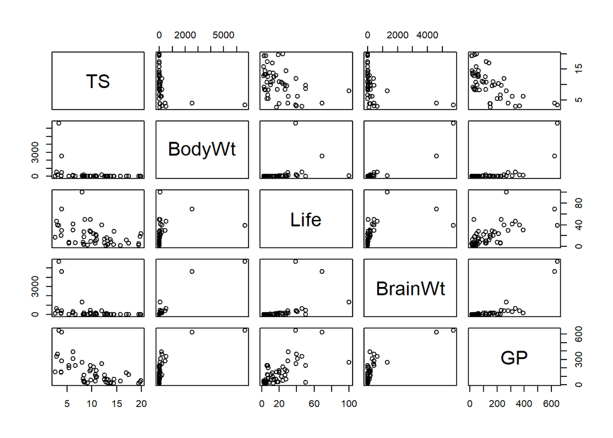

```r
sleepdata <- read.csv("C:/Users/aidan/Downloads/sleepdata.csv")

pairs(sleepdata[c("TS", "BodyWt", "Life", "BrainWt", "GP")])
```

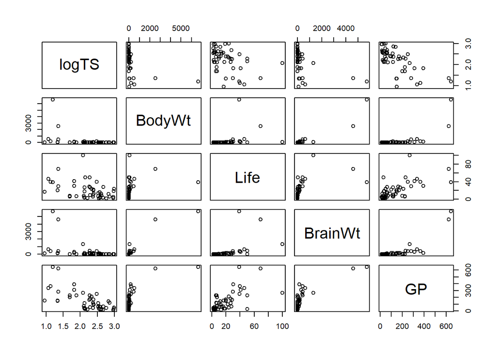

```r
sleepdata$logBodyWt = log(sleepdata$BodyWt)
sleepdata$logTS = log(sleepdata$TS)
sleepdata$logBodyWt = log(sleepdata$BodyWt)
sleepdata$logBrainWt = log(sleepdata$BrainWt)
sleepdata$logLife = log(sleepdata$Life)
sleepdata$logGP = log(sleepdata$GP)
pairs(sleepdata[c("logTS", "BodyWt", "Life", "BrainWt", "GP")])
```

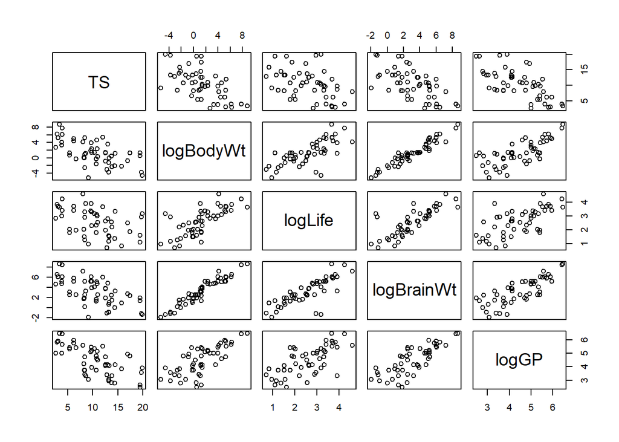

```r
pairs(sleepdata[c("TS", "logBodyWt", "logLife", "logBrainWt", "logGP")])
```

Based on the data above, it is clear that using the logarithm for the predictor variables gives us the best fit for the model. Without logarithms, nearly every single graph and relationship has extremely clumped data with no clear relationship. Taking the logarithm of the response variable does essentially nothing to change this fact. Taking the logarithm of all our predictors changes the relationships entirely, giving us primarily clear, evenly spaced relationships that look approximately linear.

# 2:

On first glance, the log of body weight, brain weight, life, and GP all appear to have an inverse linear relationship with TS. The most loose relationship looks to be with log(Life), but overall all four relationships are very similar in slope and variance. All the predictors themselves, on the other hand, have direct relationships with each other. The strongest direct relationship is with body weight and brain weight, while the weakest direct relationship is with life and gestation period. Overall, every single relationship in this model is approximately linear and consistent, making this a great starting point for statistical inference and analysis.

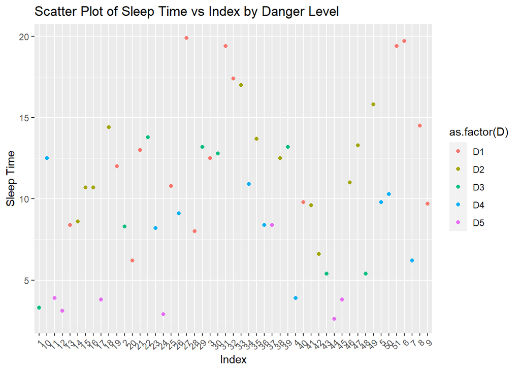

```r
plt <- rownames_to_column(sleepdata, var = "Index")



ggplot(plt, aes(x = Index, y = TS, color = as.factor(D))) +
  geom_point() +
  labs(title = "Scatter Plot of Sleep Time vs Index by Danger Level",
       x = "Index",
       y = "Sleep Time") +
  theme(axis.text.x = element_text(angle = 45, hjust = 1))
```

Based on the graph above, there is a loose correlation between sleep time and the categorical variable “D”. While there may not be enough data to say for certain, it does appear that higher levels of “D” result in less sleep time. It is most clear that D5 gives the lowest sleep time, while the other levels appear to be messier and closer in averages. While the others are messier, the trend of lower levels of “D” giving higher sleep time does remain approximately true.

### Part II: Understanding Adjusted Relationships

3. Leaving `D` in the model, describe in sentence/paragraph form the relationship between the predictors `log(BodyWt)` and `log(BrainWt)` and the response `TS` in the context of the MLR model with all predictors. As part of your written answer, be sure to address the following items/questions:
   - Use the fitted model to provide confidence intervals for the individual coefficients for `log(BodyWt)` and `log(BrainWt)` and explain what they mean in terms of the context of the problem.
   - Contrast your interpretation of the relationships between `log(BodyWt)` and `TS` (and also between `log(BrainWt)` and `TS`) under the multiple linear regression model with your description of the pairwise relationships from Part I. Describe how the interpretations differ.

# 1:

$E(TS \mid log(BodyWt),log(BrainWt), log(Life), log(GP), D) = \beta_0 + \beta_1log(BodyWt)_i + \beta_2log(BrainWt)_i +$ $\beta_3log(Life)_i + \beta_4log(GP)_i + \beta_5UD2_i + \beta_6UD3_i + \beta_7UD4_i + \beta_8UD5_i + e_i, e_i$ $\stackrel{\mathrm{iid}}{\sim} \mbox{N}(0, \sigma^2)$

```r
summary(lm(TS ~ log(BodyWt) + log(BrainWt) + log(Life) + log(GP) + D, data = sleepdata))
```

```
##
## Call:
## lm(formula = TS ~ log(BodyWt) + log(BrainWt) + log(Life) + log(GP) +
##     D, data = sleepdata)
##
## Residuals:
##     Min      1Q  Median      3Q     Max
## -6.9584 -1.3524  0.2988  1.5238  6.5396
##
## Coefficients:
##              Estimate Std. Error t value Pr(>|t|)
## (Intercept)   20.5578     2.5166   8.169 3.25e-10 ***
## log(BodyWt)    0.1012     0.4728   0.214  0.83155
## log(BrainWt)  -0.7988     0.7116  -1.123  0.26801
## log(Life)      0.5756     0.7533   0.764  0.44903
## log(GP)       -1.4749     0.6467  -2.281  0.02769 *
## DD2           -1.9756     1.1214  -1.762  0.08538 .
## DD3           -4.3761     1.3252  -3.302  0.00196 **
## DD4           -3.1764     1.2126  -2.620  0.01220 *
## DD5           -7.1567     1.3220  -5.413 2.76e-06 ***
## ---
## Signif. codes:  0 '***' 0.001 '**' 0.01 '*' 0.05 '.' 0.1 ' ' 1
##
## Residual standard error: 2.737 on 42 degrees of freedom
## Multiple R-squared:  0.7127, Adjusted R-squared:  0.658
## F-statistic: 13.03 on 8 and 42 DF,  p-value: 3.259e-09
```

# 2:

```r
null = lm(TS ~ log(BodyWt) + log(BrainWt) + log(Life) + log(GP), data = sleepdata)
alt = lm(TS ~ log(BodyWt) + log(BrainWt) + log(Life) + log(GP) + D, data = sleepdata)

df.null = null$df.residual
df.alt = alt$df.residual

RSS.alt = sum(resid(alt)^2)
RSS.null = sum(resid(null)^2)

Fstat = ((RSS.null - RSS.alt)/(df.null - df.alt)) / (RSS.alt/df.alt)

pf(Fstat, df1 = df.null - df.alt, df2 = df.alt, lower.tail=F)
```

```
## [1] 5.113642e-05
```

vs.

To solve: $\frac{\frac{RSS(null) - RSS(alt)}{df(null) - df(alt)}}{\frac{RSS(alt)}{df(alt)}}$

With a p-value of 0.0000511 being lower than my alpha level of 0.05, I have sufficient evidence to reject the null hypothesis and claim that D is a necessary predictor for our regression model.

```r
summary(null)
```

```
##
## Call:
## lm(formula = TS ~ log(BodyWt) + log(BrainWt) + log(Life) + log(GP),
##     data = sleepdata)
##
## Residuals:
##    Min     1Q Median     3Q    Max
## -6.590 -2.126 -0.110  1.991  8.247
##
## Coefficients:
##              Estimate Std. Error t value Pr(>|t|)
## (Intercept)   18.9662     3.1070   6.104 2.02e-07 ***
## log(BodyWt)   -0.3317     0.5696  -0.582  0.56320
## log(BrainWt)  -0.3621     0.8793  -0.412  0.68234
## log(Life)      1.1301     0.8893   1.271  0.21020
## log(GP)       -2.2248     0.7866  -2.828  0.00691 **
## ---
## Signif. codes:  0 '***' 0.001 '**' 0.01 '*' 0.05 '.' 0.1 ' ' 1
##
## Residual standard error: 3.497 on 46 degrees of freedom
## Multiple R-squared:  0.4862, Adjusted R-squared:  0.4415
## F-statistic: 10.88 on 4 and 46 DF,  p-value: 2.715e-06
```

```r
summary(alt)
```

```
##
## Call:
## lm(formula = TS ~ log(BodyWt) + log(BrainWt) + log(Life) + log(GP) +
##     D, data = sleepdata)
##
## Residuals:
##     Min      1Q  Median      3Q     Max
## -6.9584 -1.3524  0.2988  1.5238  6.5396
##
## Coefficients:
##              Estimate Std. Error t value Pr(>|t|)
## (Intercept)   20.5578     2.5166   8.169 3.25e-10 ***
## log(BodyWt)    0.1012     0.4728   0.214  0.83155
## log(BrainWt)  -0.7988     0.7116  -1.123  0.26801
## log(Life)      0.5756     0.7533   0.764  0.44903
## log(GP)       -1.4749     0.6467  -2.281  0.02769 *
## DD2           -1.9756     1.1214  -1.762  0.08538 .
## DD3           -4.3761     1.3252  -3.302  0.00196 **
## DD4           -3.1764     1.2126  -2.620  0.01220 *
## DD5           -7.1567     1.3220  -5.413 2.76e-06 ***
## ---
## Signif. codes:  0 '***' 0.001 '**' 0.01 '*' 0.05 '.' 0.1 ' ' 1
##
## Residual standard error: 2.737 on 42 degrees of freedom
## Multiple R-squared:  0.7127, Adjusted R-squared:  0.658
## F-statistic: 13.03 on 8 and 42 DF,  p-value: 3.259e-09
```

# 3:

```r
mult = lm(TS ~  log(BodyWt) + log(BrainWt), data = sleepdata)

confint(mult, level = 0.95)
```

```
##                  2.5 %     97.5 %
## (Intercept)   9.835835 16.6827686
## log(BodyWt)  -1.467293  0.8970482
## log(BrainWt) -2.282193  0.6863135
```

I am 95% confident that each additional log(kilogram) of body weight increases/decreases the hours of sleep per day on average by (-1.4673, 0.897). I am also 95% confident that each additional log(gram) of brain weight increases/decreases the hours of sleep per day on average by (-2.282, 0.686).

For my first interpretation of log(BodyWt) and log(BrainWt) from Part I, I claimed that both predictors generally just had an inverse relationship with the response variable, TS. My confidence intervals do support this claim to an extent, as the majority of the confidence interval is below 0, making it more likely for an inverse relationship to be present. What my interpretation from Part I failed to state, however, is that it is still quite possible that the true relationship here is not inverse at all. Since both confidence intervals contain both 0 and positive numbers, it could mean that increases in log(BrainWt) and log(BodyWt) both positively influence hours of sleep or not influence this value at all.

### Part III: Model Search Methods

```r
library(MASS)
null = lm(TS ~ 1, data = sleepdata)
full = lm(TS ~ log(BodyWt) + log(BrainWt) + log(Life) + log(GP) + D, data = sleepdata)

stepAIC(null, scope = list(upper = full),
direction = "forward", k = 2)
```

```
## Start:  AIC=158.39
## TS ~ 1
##
##                Df Sum of Sq     RSS    AIC
## + log(GP)       1    476.84  618.03 131.23
## + log(BrainWt)  1    416.10  678.77 136.01
## + log(BodyWt)   1    402.97  691.90 136.99
## + D             4    474.16  620.71 137.45
## + log(Life)     1    193.38  901.49 150.48
## <none>                      1094.87 158.40
##
## Step:  AIC=131.23
## TS ~ log(GP)
##
##                Df Sum of Sq    RSS    AIC
## + D             4   268.744 349.28 110.13
## + log(BodyWt)   1    35.151 582.88 130.24
## + log(BrainWt)  1    25.721 592.30 131.06
## <none>                      618.03 131.23
## + log(Life)     1     0.941 617.09 133.15
##
## Step:  AIC=110.13
## TS ~ log(GP) + D
##
##                Df Sum of Sq    RSS    AIC
## + log(BrainWt)  1   30.3864 318.90 107.48
## + log(BodyWt)   1   24.8139 324.47 108.37
## <none>                      349.28 110.13
## + log(Life)     1    2.0139 347.27 111.83
##
## Step:  AIC=107.48
## TS ~ log(GP) + D + log(BrainWt)
##
##               Df Sum of Sq    RSS    AIC
## <none>                     318.90 107.48
## + log(Life)    1    4.0315 314.86 108.84
## + log(BodyWt)  1    0.0015 318.89 109.48
```

```
##
## Call:
## lm(formula = TS ~ log(GP) + D + log(BrainWt), data = sleepdata)
##
## Coefficients:
##  (Intercept)       log(GP)           DD2           DD3           DD4
##      21.2179       -1.4219       -2.1651       -4.7433       -3.2938
##          DD5  log(BrainWt)
##      -7.1699       -0.5319
```

For the function above, I am starting with no predictor variables. The function then take the AIC for every model that contains one predictor and choose the lowest AIC. The function continues adding predictors until adding any predictor would result in a higher AIC than if it were to not add any more predictors.

The formula to determine the AIC is as follows:

$n \log\left(\frac{{\text{{RSSM}}_k}}{{n}}\right) + 2pM$

```r
stepAIC(full, scope = list(lower = null, upper = full),
direction = "both", k = 2)
```

```
## Start:  AIC=110.78
## TS ~ log(BodyWt) + log(BrainWt) + log(Life) + log(GP) + D
##
##                Df Sum of Sq    RSS    AIC
## - log(BodyWt)   1     0.343 314.86 108.84
## - log(Life)     1     4.373 318.89 109.48
## - log(BrainWt)  1     9.436 323.96 110.29
## <none>                      314.52 110.78
## - log(GP)       1    38.958 353.48 114.74
## - D             4   248.005 562.53 132.43
##
## Step:  AIC=108.84
## TS ~ log(BrainWt) + log(Life) + log(GP) + D
##
##                Df Sum of Sq    RSS    AIC
## - log(Life)     1     4.032 318.90 107.48
## <none>                      314.86 108.84
## + log(BodyWt)   1     0.343 314.52 110.78
## - log(BrainWt)  1    32.404 347.27 111.83
## - log(GP)       1    40.503 355.37 113.01
## - D             4   251.808 566.67 130.81
##
## Step:  AIC=107.48
## TS ~ log(BrainWt) + log(GP) + D
##
##                Df Sum of Sq    RSS    AIC
## <none>                      318.90 107.48
## + log(Life)     1     4.032 314.86 108.84
## + log(BodyWt)   1     0.001 318.89 109.48
## - log(BrainWt)  1    30.386 349.28 110.13
## - log(GP)       1    37.615 356.51 111.17
## - D             4   273.409 592.30 131.06
```

```
##
## Call:
## lm(formula = TS ~ log(BrainWt) + log(GP) + D, data = sleepdata)
##
## Coefficients:
##  (Intercept)  log(BrainWt)       log(GP)           DD2           DD3
##      21.2179       -0.5319       -1.4219       -2.1651       -4.7433
##          DD4           DD5
##      -3.2938       -7.1699
```

The function above essentially performs the reverse action of the first function. The function starts with all predictors and removes them one by one by lowest AIC until removing any predictor results in a higher AIC than not removing a predictor at all.

Model selected by search:

$\beta_0 + \beta_1log(BrainWt)_i + \beta_2log(GP)_i + \beta_3UD2_i + \beta_4UD3_i + \beta_5UD4_i + \beta_6UD5_i + e_i, e_i$ $\stackrel{\mathrm{iid}}{\sim} \mbox{N}(0, \sigma^2)$

### Part IV: Model Checking

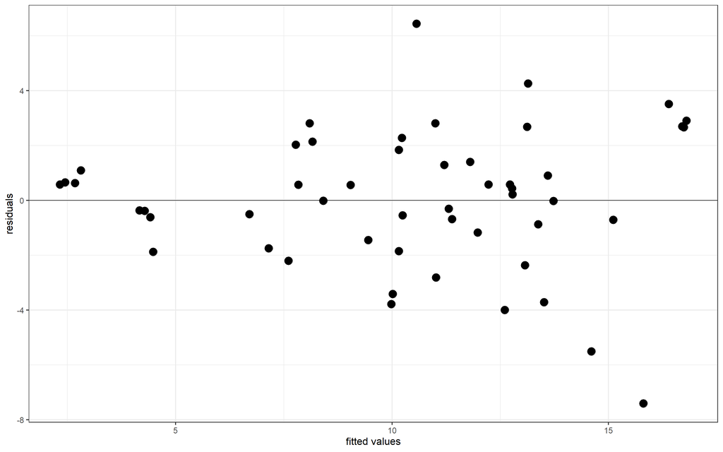

```r
model <- lm(TS ~ log(BrainWt) + log(GP) + D, data = sleepdata)

par(mfrow = c(2, 2))  # Set up a 2x2 grid for the plots

library(broom)
base = augment(model) %>% ggplot(aes(x = .fitted, y = .resid)) + geom_point(size = 6) +
  xlab("fitted values") + ylab("residuals") +
  theme_bw(16) + geom_hline(yintercept = 0)
base
```

The basic residual plot above shows a slight nonlinear trend towards the end, but overall looks to be randomly scattered with little to no trend.

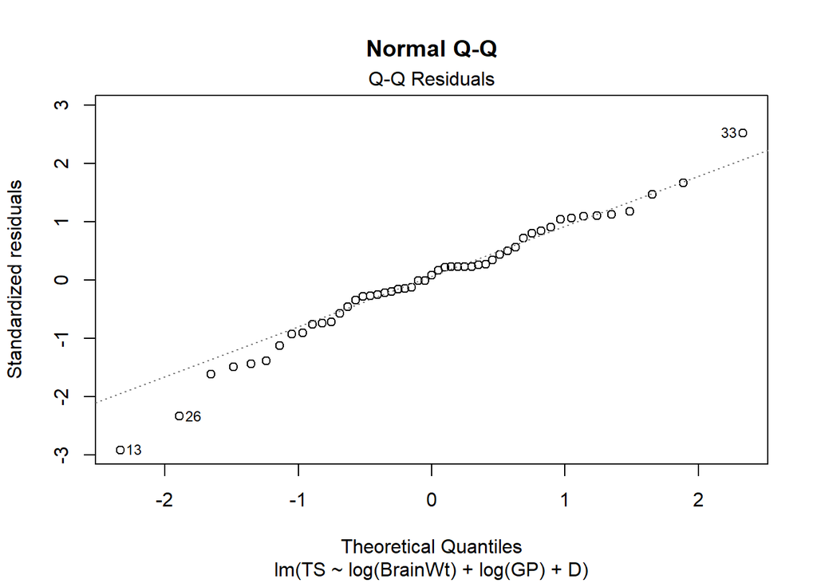

```r
plot(model, which = 2, main = "Normal Q-Q")
```

In terms of the normality of the residuals, it looks pretty good here as well. For the lower fitted values there is a bit of a deviation below the line, but the majority of the data lines up fairly well so it is safe to assume normality.

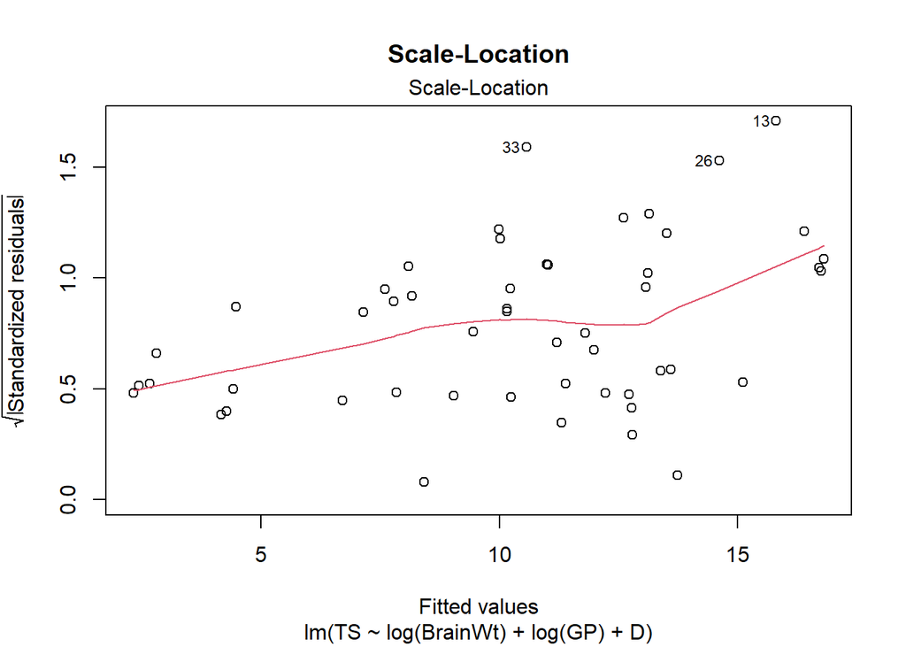

```r
plot(model, which = 3, main = "Scale-Location")
```

This visualization puts into perspective how much the nonlinear trend of the residuals towards the end of our fitted values actually affects the data. Due to this trend at the end, it may not be safe to make our typical model assumptions about the data.

### Part V: Model Summarization

# 1:

```r
model <- lm(TS ~ log(BrainWt) + log(GP) + D, data = sleepdata)

summary(model)
```

```
##
## Call:
## lm(formula = TS ~ log(BrainWt) + log(GP) + D, data = sleepdata)
##
## Residuals:
##     Min      1Q  Median      3Q     Max
## -7.4064 -1.3164  0.2171  1.6172  6.4313
##
## Coefficients:
##              Estimate Std. Error t value Pr(>|t|)
## (Intercept)   21.2179     2.2017   9.637 2.06e-12 ***
## log(BrainWt)  -0.5319     0.2597  -2.048 0.046599 *
## log(GP)       -1.4219     0.6241  -2.278 0.027628 *
## DD2           -2.1651     1.0608  -2.041 0.047277 *
## DD3           -4.7433     1.2132  -3.910 0.000316 ***
## DD4           -3.2938     1.1832  -2.784 0.007889 **
## DD5           -7.1699     1.2766  -5.616 1.23e-06 ***
## ---
## Signif. codes:  0 '***' 0.001 '**' 0.01 '*' 0.05 '.' 0.1 ' ' 1
##
## Residual standard error: 2.692 on 44 degrees of freedom
## Multiple R-squared:  0.7087, Adjusted R-squared:  0.669
## F-statistic: 17.84 on 6 and 44 DF,  p-value: 2.353e-10
```

```r
log10(1.1) * -.05319
```

```
## [1] -0.002201677
```

```r
log10(1.1) * -1.4219
```

```
## [1] -0.05885626
```

# 2:

```r
model <- lm(TS ~ BrainWt + GP + D, data = sleepdata)

library(effects)
BrainWt_effects <- effect("BrainWt*D", model)
```

```
## NOTE: BrainWt:D does not appear in the model
```

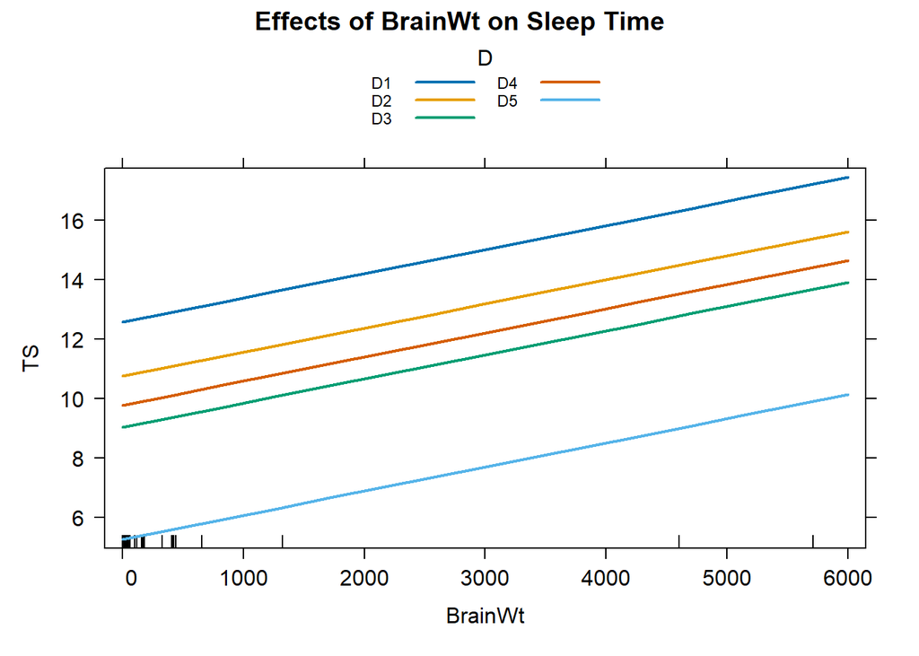

```r
plot(BrainWt_effects, multiline = TRUE, main = "Effects of BrainWt on Sleep Time")
```

```r
GP_effects <- effect("GP*D", model)
```

```
## NOTE: GP:D does not appear in the model
```

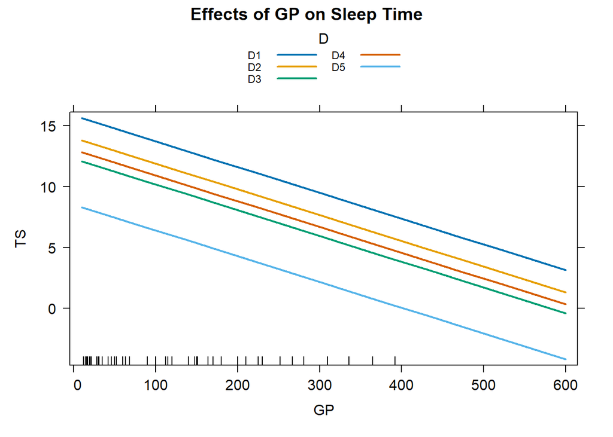

```r
plot(GP_effects, multiline = TRUE, main = "Effects of GP on Sleep Time")
```

The plots above both show that D1 results in the highest sleep time on average, while D5 results in the lowest. D5 is the lowest by a much larger margin than the other four levels. This is consistent with my claims in part 1 of this assignment. Also, a higher brain weight results in more sleep hours, while higher gestation periods result in less sleep hours. It also appears as though the gestation period has more of an effect on sleep hours than brain weight, as the slope is much steeper when the y-axis scale is taken into account.

### References

Allison, T. and Cicchetti, D. (1976). Sleep in mammals: Ecological and constitutional correlates. *Science*, 194, 732–734.

Cook, R. D. and Wesiberg, S. (1999). *Applied regression including computing and graphics*. John Wiley & Sons.